# (Ford GoBike System Data)

## by (Reem Shaya)

## Investigation Overview

> In this project, I will use Python libraries for data cleaning and data visualization in order to explore and learn about data set variables and understand data structure, anomalies, patterns, and relationships.

## Dataset Overview

> Ford GoBike is the Bay Area's bike share system, with thousands of bikes at hundreds of station in San Francisco, San Jose and the East Bay.

## (Visualization 1)

> I want to know how many customers and subscribers?

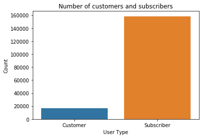

We conclude here that the number of Subscriber users is much more than customers, as the number of Subscriber users is 158,386 and the number of customers is only 16,566

## (Visualization 2)

> I want to know bike sharing for both males and females?

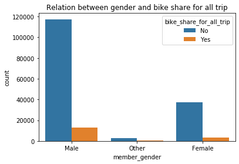

## (Visualization 3)

> I want to know the relationships between user type, gender, and time in seconds.

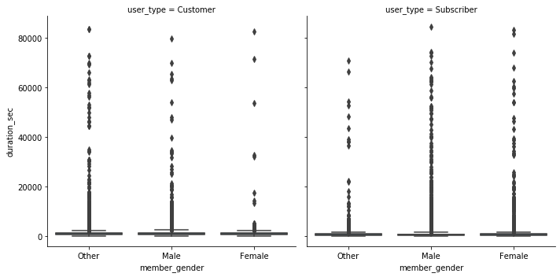

Here I put this figure to show the relationships between user type, gender, and time in seconds. We note here that the drawing was divided mainly based on the type of user, because it is in the first line of the code, as it was divided into a subscriber and a client.. Then the details were made in each form according to gender (female, male, other) and the y axis represents the time for that for a small drawing This is because we are dealing with seconds.